# Syntax Tugas Pertemuan 67

Radhitya Harma

2023-10-02

## Packages

```r
library(ggplot2)
library(tsibble)
library(tseries)
library(MASS)
library(forecast)
library(TSA)
library(TTR)
library(aTSA)
library(graphics)
```

## Input Data

```r
library(rio)
databaru <- import("https://raw.githubusercontent.com/RadhityaHarma12/MPDW/main/Pertemuan%205/databaru.csv")
databaru
```

```
##     periode      x
## 1         1  97907
## 2         2 136954
## 3         3 141112
## 4         4 128263
## 5         5 135960
## 6         6 119400
## 7         7  95011
## 8         8  91423
## 9         9 113009
## 10       10 100552
## 11       11  89003
## 12       12  94061
## 13       13  78078
## 14       14  89697
```

[output cut: 106 more lines]

## Data Time Series

Membuat data time series dari data awal

```r
databaru.ts <- ts(databaru$x)
```

Data kemudian dibagi menjadi data latih dan data uji.

```r
databaru.train <- databaru.ts[1:90]
databaru.test <- databaru.ts[91:120]
databaru.train<- ts(databaru.train)
databaru.test <- ts(databaru.test)
```

## Eksplorasi Data

Sebelum masuk dalam tahap pemodelan, dilakukan eksplorasi data dengan plot deret waktu untuk melihat pola data.

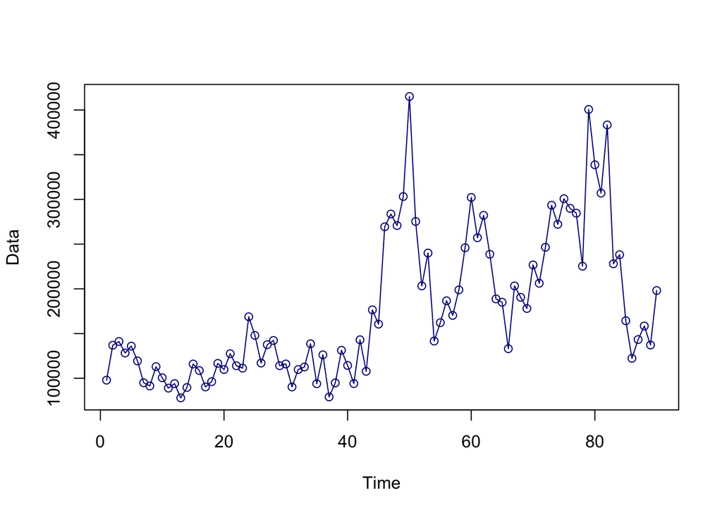

```r
#--PLOT TIME SERIES--#
plot(databaru.train,
     col = "navyblue",
     lwd = 1,
     type = "o",
     xlab = "Time",
     ylab = "Data")
```

Berdasarkan plot data deret waktu di atas, terlihat data cenderung **tidak stasioner dalam rataan dan ragam**. Data stasioner dalam rataan karena menyebar/bergerak di sekitar nilai tengahnya dan dikatakan stasioner dalam ragam karena memiliki lebar pita yang cenderung sama. Sedangkan pada plot diatas terlihat bahwa data tidak menyebar/bergerak di sekitar nilai tengahnya dan juga lebar pita yang cenderung jauh/berbeda. Selain dengan plot data deret waktu, akan dilakukan pengecekan stasioneritas data dengan plot ACF dan uji ADF.

### Plot ACF

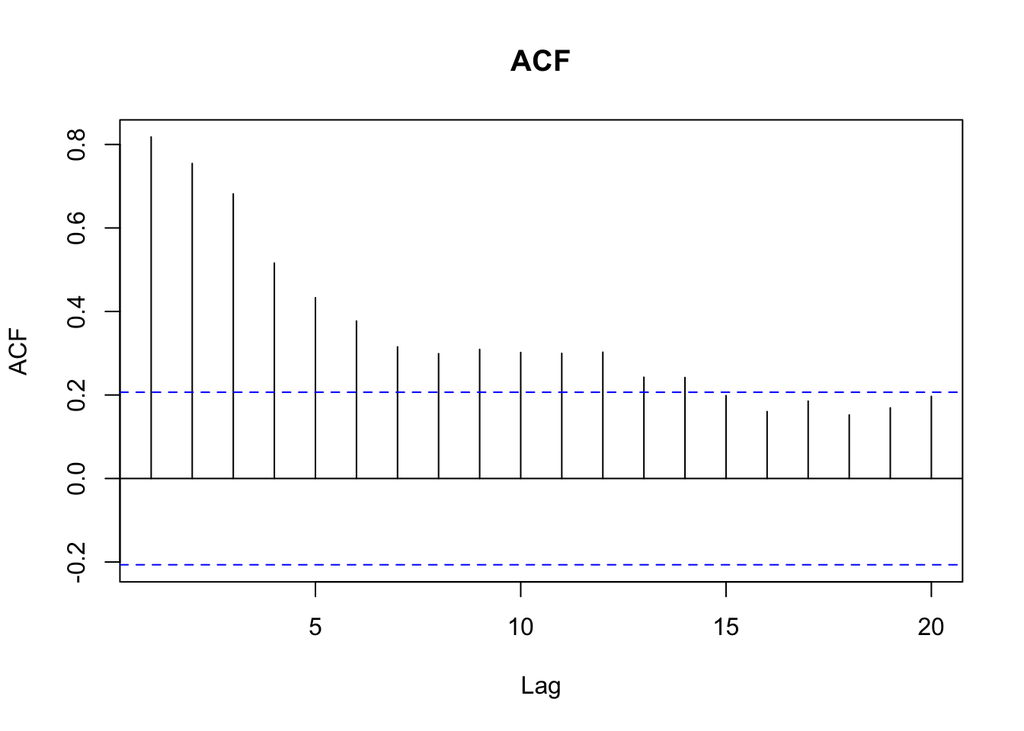

```r
acf(databaru.train, main="ACF", lag.max=20)
```

Berdasarkan plot ACF, terlihat bahwa plot ACF pada data tersebut cenderung *tails off slowly* maka data tersebut terindikasi tidak stasioner

### ADF

```r
tseries::adf.test(databaru.train, k = 6)
```

```
##
##  Augmented Dickey-Fuller Test
##
## data:  databaru.train
## Dickey-Fuller = -3.0963, Lag order = 6, p-value = 0.1248
## alternative hypothesis: stationary
```

$H_0$ : Data tidak stasioner dalam rataan

$H_1$ : Data stasioner dalam rataan

Berdasarkan uji ADF tersebut, didapat *p-value* sebesar 0.1248 yang lebih besar dari taraf nyata 5% sehingga tak tolak $H_0$ dan menandakan bahwa data tidak stasioner dalam rataan. Hal ini sesuai dengan hasil eksplorasi menggunakan plot time series dan plot ACF, sehingga ketidakstasioneran model kedepannya harus ditangani

### Boxcox

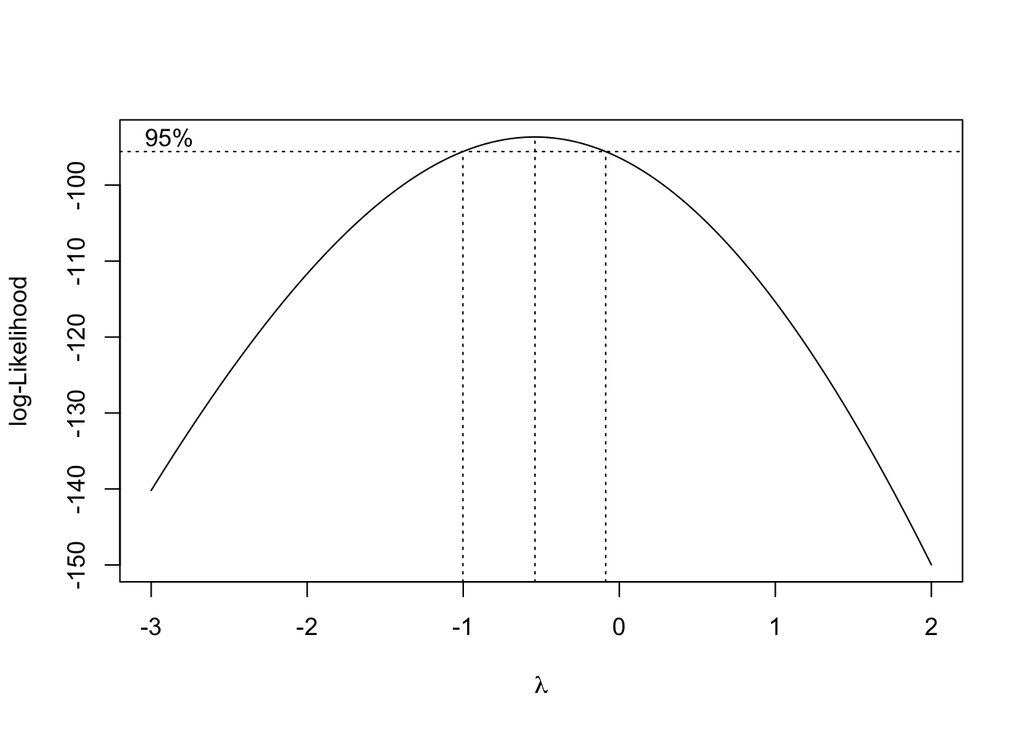

```r
index <- seq(1:90) #sebanyak row data
bc = boxcox(databaru.train~index, lambda = seq(-3,2,by=0.01))
```

```r
#Nilai Rounded Lambda
lambda <- bc$x[which.max(bc$y)]
lambda
```

```
## [1] -0.54
```

```r
#SK
bc$x[bc$y > max(bc$y) - 1/2 * qchisq(.95,1)]
```

```
##  [1] -1.00 -0.99 -0.98 -0.97 -0.96 -0.95 -0.94 -0.93 -0.92 -0.91 -0.90 -0.89
## [13] -0.88 -0.87 -0.86 -0.85 -0.84 -0.83 -0.82 -0.81 -0.80 -0.79 -0.78 -0.77
## [25] -0.76 -0.75 -0.74 -0.73 -0.72 -0.71 -0.70 -0.69 -0.68 -0.67 -0.66 -0.65
## [37] -0.64 -0.63 -0.62 -0.61 -0.60 -0.59 -0.58 -0.57 -0.56 -0.55 -0.54 -0.53
## [49] -0.52 -0.51 -0.50 -0.49 -0.48 -0.47 -0.46 -0.45 -0.44 -0.43 -0.42 -0.41
## [61] -0.40 -0.39 -0.38 -0.37 -0.36 -0.35 -0.34 -0.33 -0.32 -0.31 -0.30 -0.29
## [73] -0.28 -0.27 -0.26 -0.25 -0.24 -0.23 -0.22 -0.21 -0.20 -0.19 -0.18 -0.17
## [85] -0.16 -0.15 -0.14 -0.13 -0.12 -0.11 -0.10 -0.09
```

Plot Boxcox menunjukkan nilai *rounded value* ($\lambda$) optimum sebesar **-0.54** dan pada selang kepercayaan 95% nilai memiliki batas bawah **-1.00** dan batas atas **-0.09**. Selang tersebut tidak memuat nilai satu sehingga dapat dikatakan bahwa data bangkitan tidak stasioner dalam ragam.

## Penanganan Ketidakstasioneran Data

Plot Difference

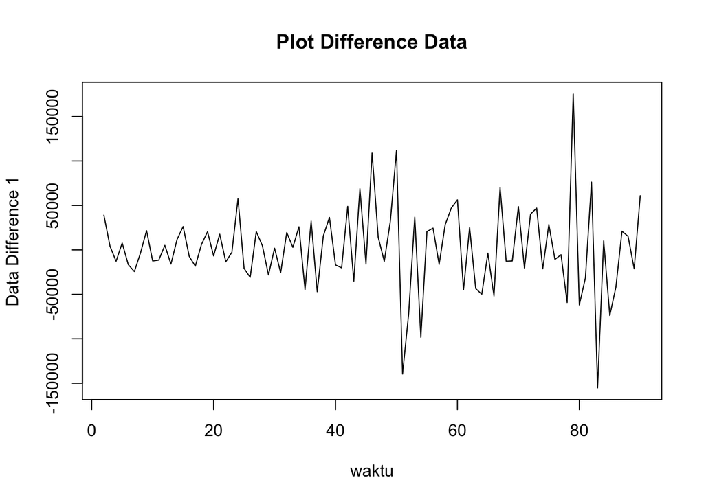

```r
databaru.diff<-diff(databaru.train,differences = 1)
plot.ts(databaru.diff, lty=1, xlab="waktu", ylab="Data Difference 1", main="Plot Difference Data")
```

Berdasarkan plot data deret waktu yang telah didifferencing, terlihat bahwa data sudah stasioner dalam rataan ditandai dengan data bergerak pada nilai tengah tertentu (tidak terdapat trend ataupun musiman pada data) ### Plot ACF

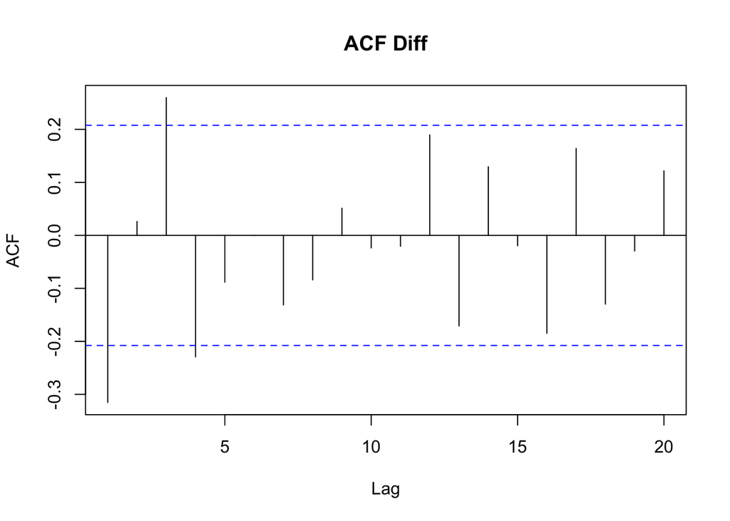

```r
acf(databaru.diff, main="ACF Diff", lag.max=20)
```

Berdasarkan plot tersebut, terlihat bahwa plot ACF cuts off pada lag ke 1. Hal ini menandakan data sudah stasioner dalam rataan dan ketidakstasioneran rataan data telah berhasil tertangani.

### ADF

```r
tseries::adf.test(databaru.diff)
```

```
##
##  Augmented Dickey-Fuller Test
##
## data:  databaru.diff
## Dickey-Fuller = -4.7899, Lag order = 4, p-value = 0.01
## alternative hypothesis: stationary
```

$H_0$ : Data tidak stasioner dalam rataan

$H_1$ : Data stasioner dalam rataan

Berdasarkan uji ADF tersebut, didapat *p-value* sebesar 0.01 yang lebih kecil dari taraf nyata 5% sehingga tolak $H_0$ atau data stasioner dalam rataan. Hal ini sesuai dengan hasil eksplorasi menggunakan plot time series dan plot ACF, sehingga dalam hal ini ketidakstasioneran data sudah berhasil ditangani dan dapat dilanjutkan ke pemodelan

## Identifikasi Model

### Plot ACF

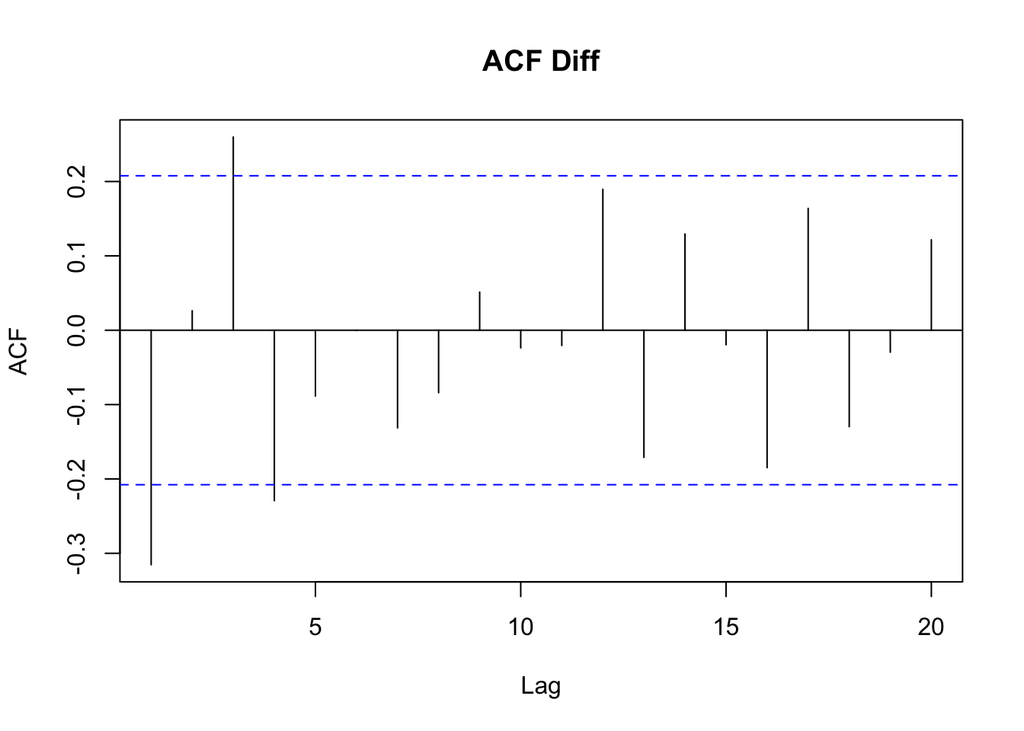

```r
acf(databaru.diff, main="ACF Diff", lag.max=20)
```

Berdasarkan plot tersebut, terlihat bahwa plot ACF cenderung *cuts off* pada lag ke 1, sehingga jika plot PACF dianggap *cuts off*, maka model tentatifnya adalah ARIMA(0,1,1).

### Plot PACF

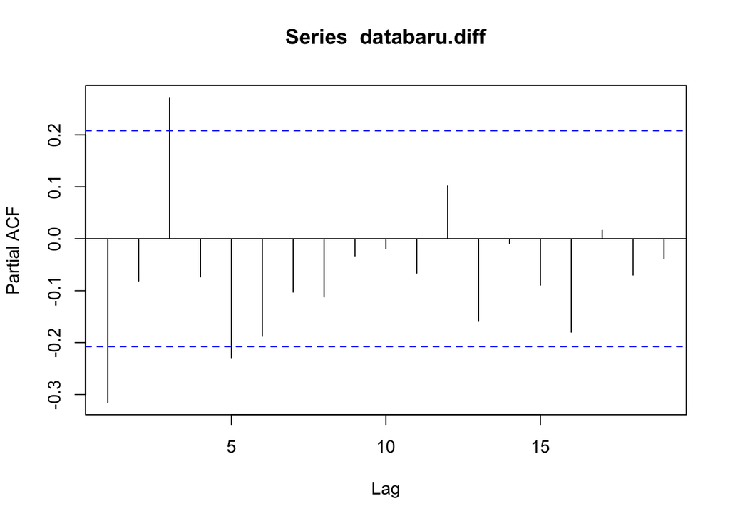

```r
pacf(databaru.diff)
```

Berdasarkan plot tersebut, terlihat bahwa plot PACF cenderung *cuts off* pada lag ke 1, sehingga jika plot ACF dianggap *cuts off*, maka model tentatifnya adalah ARIMA(1,1,0).

### Plot EACF

```r
eacf(databaru.diff)
```

```
## AR/MA
##   0 1 2 3 4 5 6 7 8 9 10 11 12 13
## 0 x o x x o o o o o o o  o  o  o
## 1 x o x x o o o o o o o  o  o  o
## 2 x x o x o o o o o o o  o  o  o
## 3 x x o o o o o o o o o  o  o  o
## 4 x x o o o o o o o o o  o  o  o
## 5 x o o o o o o o o o o  o  o  o
## 6 x x o o o o o o o o o  o  o  o
## 7 x x o x o o o o o o o  o  o  o
```

Identifikasi model menggunakan plot EACF dilakukan dengan melihat ujung segitiga pada pola segitiga nol. Dalam hal ini model tentatif yang terbentuk adalah ARIMA(3,1,2), ARIMA(3,1,3), ARIMA(0,1,4), dan ARIMA(1,1,4).

## Pendugaan Parameter Model Tentatif

### ARIMA(0,1,1)

```r
model1.da=Arima(databaru.diff, order=c(0,1,1),method="ML")
summary(model1.da)
```

```
## Series: databaru.diff
## ARIMA(0,1,1)
##
## Coefficients:
##           ma1
##       -1.0000
## s.e.   0.0299
##
## sigma^2 = 2.331e+09:  log likelihood = -1075.66
## AIC=2155.33   AICc=2155.47   BIC=2160.28
##
## Training set error measures:
##                     ME     RMSE      MAE      MPE     MAPE      MASE       ACF1
## Training set -1361.374 47733.79 34742.11 92.63409 106.5798 0.6133582 -0.3114485
```

```r
lmtest::coeftest(model1.da)
```

```
##
## z test of coefficients:
##
##      Estimate Std. Error z value  Pr(>|z|)
## ma1 -0.999951   0.029862 -33.485 < 2.2e-16 ***
## ---
## Signif. codes:  0 '***' 0.001 '**' 0.01 '*' 0.05 '.' 0.1 ' ' 1
```

AIC=2155.33 Peubah Signifikan

### ARIMA(1,1,0)

```r
model2.da=Arima(databaru.diff, order=c(1,1,0),method="ML")
summary(model2.da)
```

```
## Series: databaru.diff
## ARIMA(1,1,0)
##
## Coefficients:
##           ar1
##       -0.6264
## s.e.   0.0825
##
## sigma^2 = 3.673e+09:  log likelihood = -1093.68
## AIC=2191.36   AICc=2191.5   BIC=2196.32
##
## Training set error measures:
##                     ME     RMSE      MAE     MPE    MAPE      MASE       ACF1
## Training set -91.56646 59920.01 44364.45 132.574 185.449 0.7832367 -0.3716302
```

```r
lmtest::coeftest(model2.da)
```

```
##
## z test of coefficients:
##
##      Estimate Std. Error z value Pr(>|z|)
## ar1 -0.626399   0.082508  -7.592 3.15e-14 ***
## ---
## Signif. codes:  0 '***' 0.001 '**' 0.01 '*' 0.05 '.' 0.1 ' ' 1
```

AIC=2191.36 Peubah Signifikan

### ARIMA(3,1,2)

```r
model3.da=Arima(databaru.diff, order=c(3,1,2),method="ML")
summary(model3.da)
```

```
## Series: databaru.diff
## ARIMA(3,1,2)
##
## Coefficients:
##           ar1     ar2     ar3      ma1      ma2
##       -0.3925  0.0018  0.2800  -0.9087  -0.0913
## s.e.   0.2508  0.1376  0.1055   0.2484   0.2466
##
## sigma^2 = 2.01e+09:  log likelihood = -1067.28
## AIC=2146.55   AICc=2147.59   BIC=2161.42
##
## Training set error measures:
##                     ME     RMSE      MAE      MPE     MAPE      MASE
## Training set -1316.128 43291.39 30049.34 63.66117 115.2439 0.5305092
##                      ACF1
## Training set -0.002948041
```

```r
lmtest::coeftest(model3.da)
```

```
##
## z test of coefficients:
##
##       Estimate Std. Error z value  Pr(>|z|)
## ar1 -0.3924942  0.2507815 -1.5651 0.1175631
## ar2  0.0017604  0.1376299  0.0128 0.9897950
## ar3  0.2799507  0.1054985  2.6536 0.0079638 **
## ma1 -0.9086996  0.2484472 -3.6575 0.0002547 ***
## ma2 -0.0913004  0.2465576 -0.3703 0.7111587
## ---
## Signif. codes:  0 '***' 0.001 '**' 0.01 '*' 0.05 '.' 0.1 ' ' 1
```

AIC=2146.55 Peubah Tidak Signifikan

### ARIMA(3,1,3)

```r
model4.da=Arima(databaru.diff, order=c(3,1,3),method="ML")
summary(model4.da)
```

```
## Series: databaru.diff
## ARIMA(3,1,3)
##
## Coefficients:
##           ar1      ar2     ar3      ma1     ma2      ma3
##       -0.2993  -0.3086  0.1904  -1.0136  0.4158  -0.4022
## s.e.   0.3072   0.2498  0.1414   0.3087  0.4307   0.2377
##
## sigma^2 = 1.98e+09:  log likelihood = -1066.15
## AIC=2146.3   AICc=2147.7   BIC=2163.64
##
## Training set error measures:
##                    ME     RMSE      MAE     MPE     MAPE      MASE
## Training set -1319.97 42712.39 29983.09 64.6522 119.8979 0.5293396
##                       ACF1
## Training set -0.0005216676
```

```r
lmtest::coeftest(model4.da)
```

```
##
## z test of coefficients:
##
##     Estimate Std. Error z value Pr(>|z|)
## ar1 -0.29931    0.30725 -0.9742 0.329976
## ar2 -0.30862    0.24980 -1.2355 0.216653
## ar3  0.19044    0.14143  1.3465 0.178142
## ma1 -1.01356    0.30875 -3.2828 0.001028 **
## ma2  0.41580    0.43067  0.9655 0.334315
## ma3 -0.40221    0.23774 -1.6918 0.090687 .
## ---
## Signif. codes:  0 '***' 0.001 '**' 0.01 '*' 0.05 '.' 0.1 ' ' 1
```

AIC=2146.3 Peubah tidak Signifikan

### ARIMA(0,1,4)

```r
model5.da=Arima(databaru.diff, order=c(0,1,4),method="ML")
summary(model5.da)
```

```
## Series: databaru.diff
## ARIMA(0,1,4)
##
## Coefficients:
##           ma1     ma2     ma3      ma4
##       -1.2617  0.4832  0.0073  -0.2288
## s.e.   0.1204  0.2054  0.2154   0.1216
##
## sigma^2 = 2.016e+09:  log likelihood = -1067.77
## AIC=2145.54   AICc=2146.27   BIC=2157.92
##
## Training set error measures:
##                 ME     RMSE      MAE      MPE     MAPE      MASE        ACF1
## Training set -1420 43616.79 30951.04 77.11923 115.5978 0.5464283 -0.04910957
```

```r
lmtest::coeftest(model5.da)
```

```
##
## z test of coefficients:
##
##       Estimate Std. Error  z value Pr(>|z|)
## ma1 -1.2617052  0.1204399 -10.4758  < 2e-16 ***
## ma2  0.4832192  0.2053577   2.3531  0.01862 *
## ma3  0.0073387  0.2154068   0.0341  0.97282
## ma4 -0.2287927  0.1216400  -1.8809  0.05999 .
## ---
## Signif. codes:  0 '***' 0.001 '**' 0.01 '*' 0.05 '.' 0.1 ' ' 1
```

AIC=2145.54 Peubah tidak signifikan

### ARIMA(1,1,4)

```r
model6.da=Arima(databaru.diff, order=c(1,1,4),method="ML")
summary(model6.da)
```

```
## Series: databaru.diff
## ARIMA(1,1,4)
##
## Coefficients:
##           ar1      ma1      ma2     ma3      ma4
##       -0.4446  -0.8400  -0.0717  0.2608  -0.3488
## s.e.   0.2520   0.2375   0.3007  0.1507   0.1003
##
## sigma^2 = 1.988e+09:  log likelihood = -1066.73
## AIC=2145.46   AICc=2146.5   BIC=2160.33
##
## Training set error measures:
##                     ME     RMSE      MAE      MPE    MAPE      MASE        ACF1
## Training set -1387.178 43061.94 30582.38 71.37987 117.605 0.5399198 -0.02818843
```

```r
lmtest::coeftest(model6.da)
```

```
##
## z test of coefficients:
##
##      Estimate Std. Error z value  Pr(>|z|)
## ar1 -0.444570   0.251958 -1.7645 0.0776546 .
## ma1 -0.840001   0.237513 -3.5366 0.0004052 ***
## ma2 -0.071745   0.300712 -0.2386 0.8114273
## ma3  0.260770   0.150705  1.7303 0.0835710 .
## ma4 -0.348790   0.100349 -3.4758 0.0005094 ***
## ---
## Signif. codes:  0 '***' 0.001 '**' 0.01 '*' 0.05 '.' 0.1 ' ' 1
```

AIC=2145.46 Peubah tidak signifikan

## Analisis Sisaan

Model terbaik hasil identifikasi kemudian dicek asumsi sisaannya. Sisaan model ARIMA harus memenuhi asumsi normalitas, kebebasan sisaan, dan kehomogenan ragam. Diagnostik model dilakukan secara eksplorasi dan uji formal.

#### Eksplorasi Sisaan ARIMA (0,1,1)

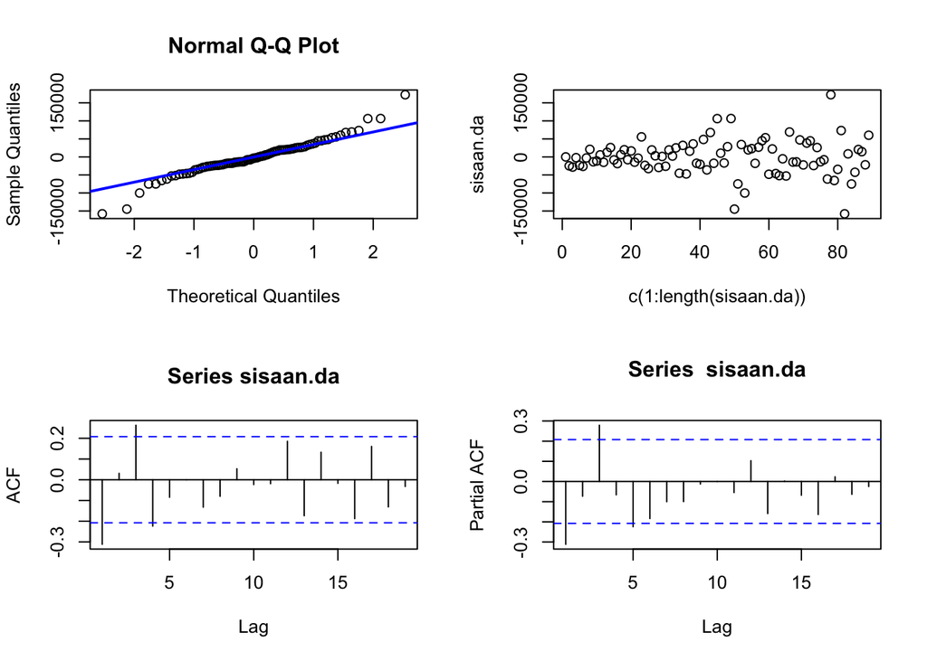

```r
#Eksplorasi
sisaan.da <- model1.da$residuals
par(mfrow=c(2,2))
qqnorm(sisaan.da)
qqline(sisaan.da, col = "blue", lwd = 2)
plot(c(1:length(sisaan.da)),sisaan.da)
acf(sisaan.da)
pacf(sisaan.da)
```

```r
par(mfrow = c(1,1))
```

Berdasarkan plot kuantil-kuantil normal, secara eksplorasi ditunjukkan sisaan tidak menyebar normal ditandai dengan titik titik yang cenderung tidak mengikuti garis $45^{\circ}$. Kemudian dapat dilihat juga lebar pita sisaan yang cenderung tidak sama menandakan bahwa sisaan memiliki ragam yang heterogen. Plot ACF dan PACF sisaan ARIMA(0,1,1) signifikan pada lag ke-1 yang menandakan tidak saling bebas. Kondisi ini akan diuji lebih lanjut dengan uji formal.

## Uji Formal

### 1. Sisaan Menyebar Normal

```r
ks.test(sisaan.da,"pnorm")  #tak tolak H0 > sisaan menyebar normal
```

```
##
##  Exact one-sample Kolmogorov-Smirnov test
##
## data:  sisaan.da
## D = 0.52809, p-value < 2.2e-16
## alternative hypothesis: two-sided
```

Selain dengan eksplorasi, asumsi tersebut dapat diuji menggunakan uji formal. Pada tahapan ini uji formal yang digunakan untuk normalitas adalah uji Kolmogorov-Smirnov (KS). Hipotesis pada uji KS adalah sebagai berikut.

$H_0$ : Sisaan menyebar normal

$H_1$ : Sisaan tidak menyebar normal

Berdasarkan uji KS tersebut, didapat *p-value* sebesar < 2.2e-16 yang kurang dari taraf nyata 5% sehingga tolak $H_0$ dan menandakan bahwa sisaan tidak menyebar normal. Hal ini sesuai dengan hasil eksplorasi menggunakan plot kuantil-kuantil normal.

### 2. Sisaan Saling bebas/tidak ada autokorelasi

```r
Box.test(sisaan.da, type = "Ljung")  #tak tolak H0 > sisaan saling bebas
```

```
##
##  Box-Ljung test
##
## data:  sisaan.da
## X-squared = 8.9273, df = 1, p-value = 0.002809
```

Selanjutnya akan dilakukan uji formal untuk kebebasan sisaan menggunakan uji Ljung-Box. Hipotesis yang digunakan adalah sebagai berikut.

$H_0$ : Sisaan saling bebas

$H_1$ : Sisaan tidak tidak saling bebas

Berdasarkan uji Ljung-Box tersebut, didapat *p-value* sebesar 0.002809 yang lebih kecil dari taraf nyata 5% sehingga tolak $H_0$ dan menandakan bahwa sisaan tidak saling bebas. ### 3. Sisaan homogen

```r
Box.test((sisaan.da)^2, type = "Ljung")  #tak tolak H0 > sisaan homogen
```

```
##
##  Box-Ljung test
##
## data:  (sisaan.da)^2
## X-squared = 3.2585, df = 1, p-value = 0.07105
```

Hipotesis yang digunakan untuk uji kehomogenan ragam adalah sebagai berikut.

$H_0$ : Ragam sisaan homogen

$H_1$ : Ragam sisaan tidak homogen

### 4. Nilai tengah sisaan sama dengan nol

```r
t.test(sisaan.da, mu = 0, conf.level = 0.95)  #tak tolak h0 > nilai tengah sisaan sama dengan 0
```

```
##
##  One Sample t-test
##
## data:  sisaan.da
## t = -0.26765, df = 88, p-value = 0.7896
## alternative hypothesis: true mean is not equal to 0
## 95 percent confidence interval:
##  -11469.463   8746.715
## sample estimates:
## mean of x
## -1361.374
```

Terakhir, dengan uji-t, akan dicek apakah nilai tengah sisaan sama dengan nol. Hipotesis yang diujikan sebagai berikut.

$H_0$ : nilai tengah sisaan sama dengan 0

$H_1$ : nilai tengah sisaan tidak sama dengan 0

Berdasarkan uji-ttersebut, didapat *p-value* sebesar 0.7896 yang lebih besar dari taraf nyata 5% sehingga tak tolak $H_0$ dan menandakan bahwa nilai tengah sisaan sama dengan nol.